# Mapping isolates to feedback

Thoenen_et_al_BX_tolerance

Lisa Thoenen

2023-09-08

Here we analyse the mapping output of the maize root bacteria isolates. We investigate how abundant the isolate corresponding ASVs are in the root microbiome of wild-type B73 maize plants grown in wild-type conditioned field soil in the greenhouse.

# SetUp

Load the required packages and functions.

## Design table

This is how the design table looks like:

```
##                   sample_id nr       exp compartment                soil
## R3_1193R_F18_799F     soil1 35 field_exp        Soil unconditioned_field
## R3_1193R_F28_799F     soil3 38 field_exp        Soil unconditioned_field
## R3_1193R_F29_799F     soil5 40 field_exp        Soil unconditioned_field
##                   soil_sample genotype DNA_extraction  bc_799F bc_1193R
## R3_1193R_F18_799F          S1       no         serie1 F18_799F R3_1193R
## R3_1193R_F28_799F          S3       no         serie1 F28_799F R3_1193R
## R3_1193R_F29_799F          S5       no         serie1 F29_799F R3_1193R
##                                F_primer_16s               R_primer_16S
## R3_1193R_F18_799F CCTAAGAACMGGATTAGATACCCKG GACACAGTACGTCATCCCCACCTTCC
## R3_1193R_F28_799F GGAGAAAACMGGATTAGATACCCKG GACACAGTACGTCATCCCCACCTTCC
## R3_1193R_F29_799F GGATCTAACMGGATTAGATACCCKG GACACAGTACGTCATCCCCACCTTCC
##                   padding_seq_16S MiSeq_16S   sample_list_16S  bc_ITS1F
## R3_1193R_F18_799F              no     run02 R3_1193R_F18_799F F47_ITS1F
## R3_1193R_F28_799F              no     run02 R3_1193R_F28_799F F48_ITS1F
## R3_1193R_F29_799F              no     run02 R3_1193R_F29_799F F48_ITS1F
##                    bc_ITS2                        F_primer_its
## R3_1193R_F18_799F  R8_ITS2 GGTAGACAACAGCCTTGGTCATTTAGAGGAAGTAA
## R3_1193R_F28_799F R10_ITS2 GGTAGCAACACAGCTTGGTCATTTAGAGGAAGTAA
## R3_1193R_F29_799F R11_ITS2 GGTAGCAACACAGCTTGGTCATTTAGAGGAAGTAA
##                                        R_primer_its padding_seq_its MiSeq_its
## R3_1193R_F18_799F GGTAGTGTCACACGCTGCGTTCTTCATCGATGC           GGTAG     run11
## R3_1193R_F28_799F GGTAGTATGCGGTGCTGCGTTCTTCATCGATGC           GGTAG     run11
## R3_1193R_F29_799F GGTAGGTGATCCAGCTGCGTTCTTCATCGATGC           GGTAG     run11
##                      sample_list_its     groups    cols
## R3_1193R_F18_799F  R8_ITS2_F47_ITS1F field_soil dimgrey
## R3_1193R_F28_799F R10_ITS2_F48_ITS1F field_soil dimgrey
## R3_1193R_F29_799F R11_ITS2_F48_ITS1F field_soil dimgrey
```

## Count table

```
##                   sample_id nr       exp compartment                soil
## R3_1193R_F18_799F     soil1 35 field_exp        Soil unconditioned_field
## R3_1193R_F28_799F     soil3 38 field_exp        Soil unconditioned_field
## R3_1193R_F29_799F     soil5 40 field_exp        Soil unconditioned_field
## R3_1193R_F25_799F    soil10 36 field_exp        Soil unconditioned_field
## R3_1193R_F27_799F     soil4 39 field_exp        Soil unconditioned_field
## R3_1193R_F37_799F     soil7 42 field_exp        Soil unconditioned_field
##                   soil_sample genotype DNA_extraction  bc_799F bc_1193R
## R3_1193R_F18_799F          S1       no         serie1 F18_799F R3_1193R
## R3_1193R_F28_799F          S3       no         serie1 F28_799F R3_1193R
## R3_1193R_F29_799F          S5       no         serie1 F29_799F R3_1193R
## R3_1193R_F25_799F         S10       no         serie2 F25_799F R3_1193R
## R3_1193R_F27_799F          S4       no         serie2 F27_799F R3_1193R
## R3_1193R_F37_799F          S7       no         serie1 F37_799F R3_1193R
##                                F_primer_16s               R_primer_16S
## R3_1193R_F18_799F CCTAAGAACMGGATTAGATACCCKG GACACAGTACGTCATCCCCACCTTCC
## R3_1193R_F28_799F GGAGAAAACMGGATTAGATACCCKG GACACAGTACGTCATCCCCACCTTCC
## R3_1193R_F29_799F GGATCTAACMGGATTAGATACCCKG GACACAGTACGTCATCCCCACCTTCC
## R3_1193R_F25_799F GCACTAAACMGGATTAGATACCCKG GACACAGTACGTCATCCCCACCTTCC
## R3_1193R_F27_799F GCTTGAAACMGGATTAGATACCCKG GACACAGTACGTCATCCCCACCTTCC
## R3_1193R_F37_799F TGGAAGAACMGGATTAGATACCCKG GACACAGTACGTCATCCCCACCTTCC
##                   padding_seq_16S MiSeq_16S   sample_list_16S  bc_ITS1F
## R3_1193R_F18_799F              no     run02 R3_1193R_F18_799F F47_ITS1F
## R3_1193R_F28_799F              no     run02 R3_1193R_F28_799F F48_ITS1F
## R3_1193R_F29_799F              no     run02 R3_1193R_F29_799F F48_ITS1F
## R3_1193R_F25_799F              no     run02 R3_1193R_F25_799F F48_ITS1F
## R3_1193R_F27_799F              no     run02 R3_1193R_F27_799F F48_ITS1F
## R3_1193R_F37_799F              no     run02 R3_1193R_F37_799F F49_ITS1F
##                    bc_ITS2                        F_primer_its
## R3_1193R_F18_799F  R8_ITS2 GGTAGACAACAGCCTTGGTCATTTAGAGGAAGTAA
## R3_1193R_F28_799F R10_ITS2 GGTAGCAACACAGCTTGGTCATTTAGAGGAAGTAA
## R3_1193R_F29_799F R11_ITS2 GGTAGCAACACAGCTTGGTCATTTAGAGGAAGTAA
## R3_1193R_F25_799F  R7_ITS2 GGTAGCAACACAGCTTGGTCATTTAGAGGAAGTAA
## R3_1193R_F27_799F  R9_ITS2 GGTAGCAACACAGCTTGGTCATTTAGAGGAAGTAA
## R3_1193R_F37_799F R11_ITS2 GGTAGGCCAATACCTTGGTCATTTAGAGGAAGTAA
##                                        R_primer_its padding_seq_its MiSeq_its
## R3_1193R_F18_799F GGTAGTGTCACACGCTGCGTTCTTCATCGATGC           GGTAG     run11
## R3_1193R_F28_799F GGTAGTATGCGGTGCTGCGTTCTTCATCGATGC           GGTAG     run11
## R3_1193R_F29_799F GGTAGGTGATCCAGCTGCGTTCTTCATCGATGC           GGTAG     run11
## R3_1193R_F25_799F GGTAGTTCGGCTAGCTGCGTTCTTCATCGATGC           GGTAG     run11
## R3_1193R_F27_799F GGTAGTCTTCGACGCTGCGTTCTTCATCGATGC           GGTAG     run11
## R3_1193R_F37_799F GGTAGGTGATCCAGCTGCGTTCTTCATCGATGC           GGTAG     run11
##                      sample_list_its     groups    cols
## R3_1193R_F18_799F  R8_ITS2_F47_ITS1F field_soil dimgrey
## R3_1193R_F28_799F R10_ITS2_F48_ITS1F field_soil dimgrey
## R3_1193R_F29_799F R11_ITS2_F48_ITS1F field_soil dimgrey
## R3_1193R_F25_799F  R7_ITS2_F48_ITS1F field_soil dimgrey
## R3_1193R_F27_799F  R9_ITS2_F48_ITS1F field_soil dimgrey
## R3_1193R_F37_799F R11_ITS2_F49_ITS1F field_soil dimgrey
```

This is how the count table looks like:

```
##      F61_799F_R40_1193R F61_799F_R41_1193R F61_799F_R42_1193R
## ASV1               1476                444                439
## ASV2                540                224                235
## ASV3                643                167                253
## ASV4                131                 92                130
## ASV5                257                 96                131
##      F61_799F_R43_1193R F61_799F_R44_1193R
## ASV1                601               1334
## ASV2                321                  0
## ASV3                257                 32
## ASV4                679                610
## ASV5                277                137
```

## Taxonomy table

This is how the taxonomy table looks like:

```
##              phylum                 order       genus
## ASV1 Proteobacteria      Sphingomonadales Sphingobium
## ASV2    Chloroflexi        Chloroflexales        <NA>
## ASV3    Chloroflexi        Chloroflexales        <NA>
## ASV4 Proteobacteria Betaproteobacteriales   Pelomonas
## ASV5    Chloroflexi        Chloroflexales        <NA>
```

## Experimental design

| groups_experiment_soil | Samples |
| --- | --- |
| bx1_Rhizo_field_exp_unconditioned_field | 7 |
| bx1_Root_field_exp_unconditioned_field | 7 |
| no_Soil_field_exp_unconditioned_field | 10 |
| WT_Rhizo_feedback_BX- | 10 |
| WT_Rhizo_feedback_BX+ | 10 |
| WT_Rhizo_field_exp_unconditioned_field | 10 |
| WT_Root_feedback_BX- | 10 |
| WT_Root_feedback_BX+ | 10 |
| WT_Root_field_exp_unconditioned_field | 10 |

# Mapping bacterial isolates to microbiota members

| Nr | ASV | Strain | % |
| --- | --- | --- | --- |
| 1 | ASV1 | LSP13_27f | 1 |
| 2 | ASV1 | LSP13_1492r | 1 |
| 3 | ASV1 | LMA1_1492r | 1 |
| 4 | ASV1 | LMC3_1492r | 1 |
| 5 | ASV1 | LBH1_1492r | 1 |
| 6 | ASV1 | LBH2_1492r | 1 |

### Abundance psmelt new mapping

LMX92 & LMX9231 were in the wrong direction in the sequences used for the mapping, but they are almost 100 % similar to LME3, therefore it will be the same mapping result.

Strains to remove: strange sequence that maps to a lot of ASVs - LAT1 - LBH1 - LBH4 - LBH6 - LTA5 - LWH2 - LWH6 - LWO4

#### Display mapped ASV in rank abundance plot

```
## [1] 245
```

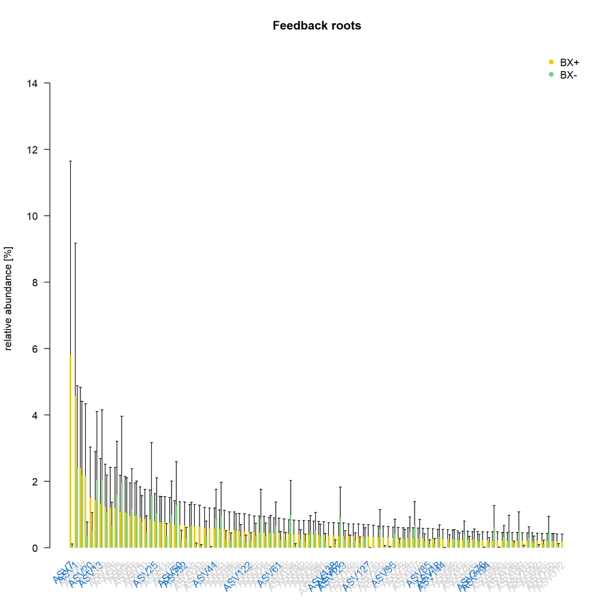

#### Isolates in Rhizosphere microbiome

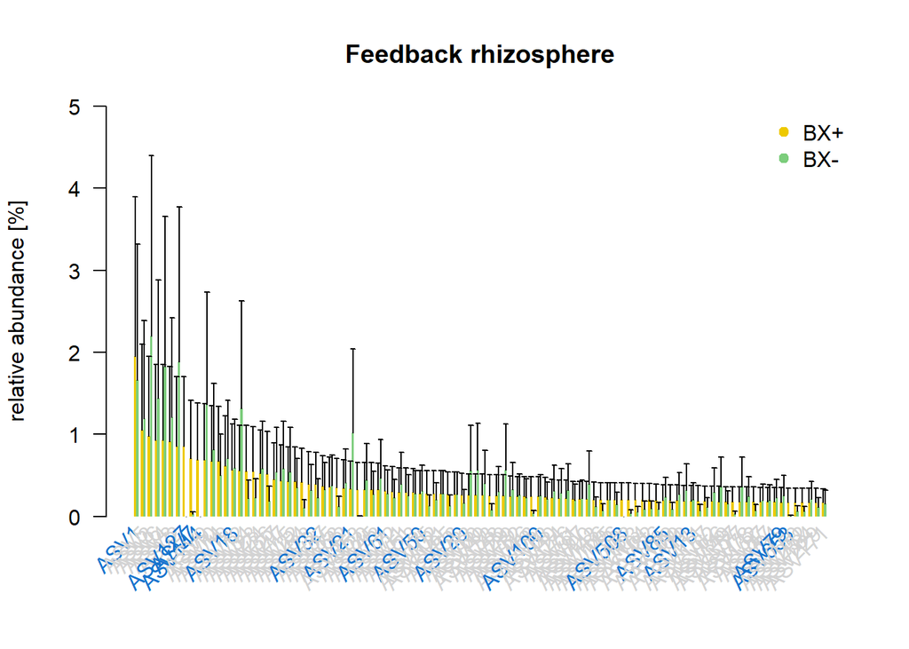

#### Identity mapped ASV sorted abundance mean

all_phy_psmelt_FB_BXp_iso_new_mapping_onlyASVtax = a table where there is abundance of each mapped ASV with taxonomy

sum all relative abundances in total of all represented ASVs

```
## # A tibble: 170 × 5
## # Groups:   genus [38]
##    phylum              family            genus               soil  Abundace_mean
##    <chr>               <chr>             <chr>               <fct>         <dbl>
##  1 Deinococcus-Thermus Deinococcaceae    Deinococcus         BX+           5.82
##  2 Proteobacteria      Sphingomonadaceae Sphingobium         BX+           4.59
##  3 Proteobacteria      Rhizobiaceae      Allorhizobium-Neor… BX+           1.52
##  4 Actinobacteria      Streptomycetaceae Streptomyces        BX+           1.34
##  5 Actinobacteria      Streptomycetaceae Streptomyces        BX+           0.813
##  6 Proteobacteria      Burkholderiaceae  Pseudoduganella     BX+           0.695
##  7 Proteobacteria      Sphingomonadaceae Sphingobium         BX+           0.688
##  8 Actinobacteria      Streptomycetaceae Streptomyces        BX+           0.594
##  9 Actinobacteria      Microbacteriaceae Microbacterium      BX+           0.495
## 10 Proteobacteria      Pseudomonadaceae  Pseudomonas         BX+           0.444
## # ℹ 160 more rows
```

```
## [1] 110
```

```
## [1] 20
```

```
##                    x freq
## 1        Bacillaceae    1
## 2   Burkholderiaceae    1
## 3     Deinococcaceae    1
## 4 Enterobacteriaceae    2
## 5  Microbacteriaceae    2
## 6   Pseudomonadaceae    2
## 7       Rhizobiaceae    3
## 8  Sphingomonadaceae    3
## 9  Streptomycetaceae    5
```

```
## [1] 94
```

```
## [1] 10
```

| Compartment | Selection_ASV | Mapped_abundance | Total_abundance | Percent_isolated |
| --- | --- | --- | --- | --- |
| Root | total | 23.898658 | 99.96357 | 23.90737 |
| Root | top50 | 17.000585 | 48.10250 | 35.34242 |
| Root | top100 | 20.087138 | 62.25178 | 32.26757 |
| Rhizo | total | 10.373241 | 99.98322 | 10.37498 |
| Rhizo | top50 | 6.337912 | 25.68281 | 24.67765 |
| Rhizo | top100 | 7.512048 | 35.80532 | 20.98025 |

| sum_abundance |
| --- |
| 23.89866 |
| 10.37324 |

## Cumulative abundance to plot in tax tree

Abundance, BXcol table for phylogenetic tree Fig. 1

# Families in microbiome

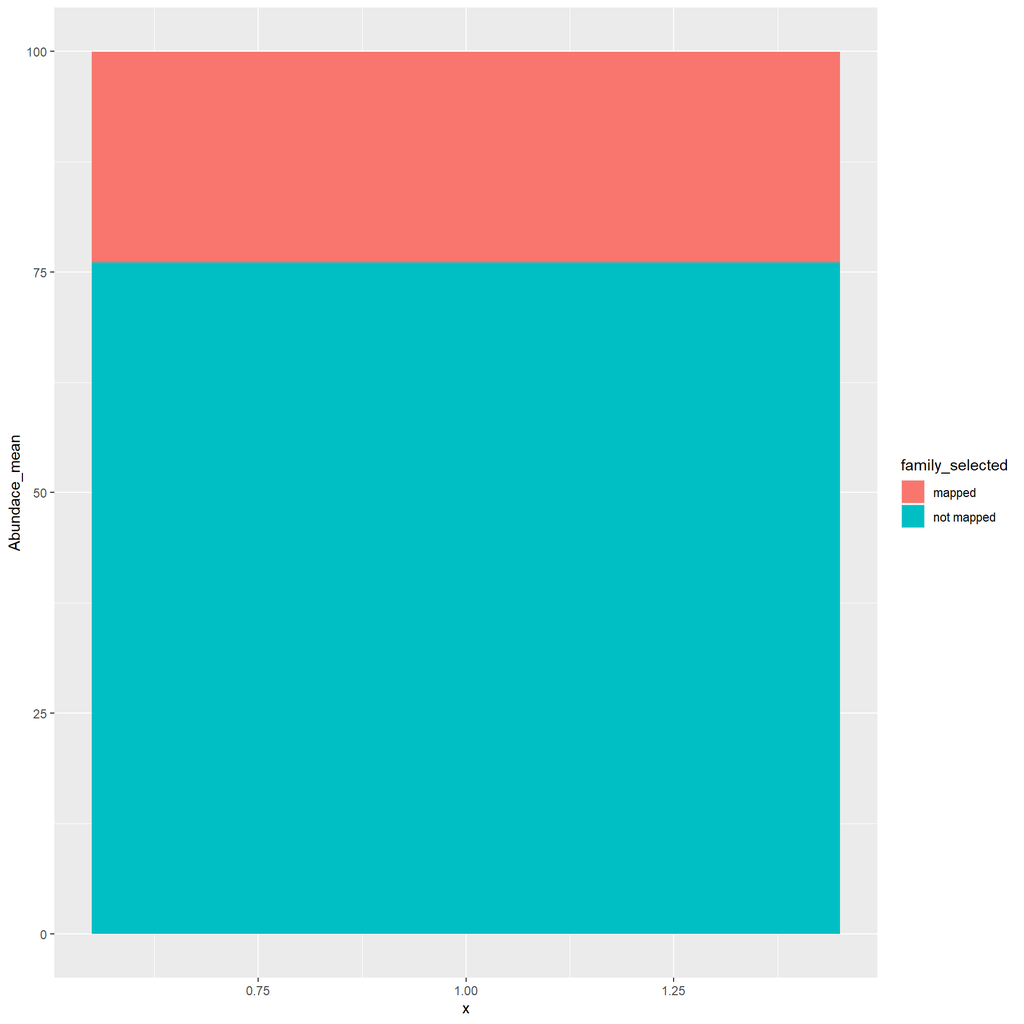

| OTU | phylum | family | genus | soil | Abundace_mean | family_selected |
| --- | --- | --- | --- | --- | --- | --- |
| ASV7 | Deinococcus-Thermus | Deinococcaceae | Deinococcus | BX+ | 5.8221609 | mapped |
| ASV1 | Proteobacteria | Sphingomonadaceae | Sphingobium | BX+ | 4.5870719 | mapped |
| ASV20 | Proteobacteria | Rhizobiaceae | Allorhizobium-Neorhizobium-Pararhizobium-Rhizobium | BX+ | 1.5174808 | mapped |
| ASV13 | Actinobacteria | Streptomycetaceae | Streptomyces | BX+ | 1.3448510 | mapped |
| ASV25 | Actinobacteria | Streptomycetaceae | Streptomyces | BX+ | 0.8129257 | mapped |
| ASV50 | Proteobacteria | Burkholderiaceae | Pseudoduganella | BX+ | 0.6947706 | mapped |
| ASV32 | Proteobacteria | Sphingomonadaceae | Sphingobium | BX+ | 0.6876852 | mapped |
| ASV44 | Actinobacteria | Streptomycetaceae | Streptomyces | BX+ | 0.5943788 | mapped |
| ASV122 | Actinobacteria | Microbacteriaceae | Microbacterium | BX+ | 0.4948430 | mapped |
| ASV61 | Proteobacteria | Pseudomonadaceae | Pseudomonas | BX+ | 0.4444178 | mapped |
| ASV138 | Proteobacteria | Pseudomonadaceae | Pseudomonas | BX+ | 0.3780560 | mapped |
| ASV57 | Actinobacteria | Streptomycetaceae | Streptomyces | BX+ | 0.3710833 | mapped |
| ASV129 | Actinobacteria | Microbacteriaceae | Microbacterium | BX+ | 0.3703617 | mapped |
| ASV127 | Proteobacteria | Enterobacteriaceae | NA | BX+ | 0.3463999 | mapped |
| ASV86 | Actinobacteria | Streptomycetaceae | Streptomyces | BX+ | 0.3086491 | mapped |
| ASV85 | Firmicutes | Bacillaceae | Bacillus | BX+ | 0.2883982 | mapped |
| ASV18 | Proteobacteria | Sphingomonadaceae | Sphingobium | BX+ | 0.2768663 | mapped |
| ASV144 | Proteobacteria | Enterobacteriaceae | Lelliottia | BX+ | 0.2743686 | mapped |
| ASV376 | Proteobacteria | Rhizobiaceae | Neorhizobium | BX+ | 0.2363631 | mapped |
| ASV194 | Proteobacteria | Rhizobiaceae | Neorhizobium | BX+ | 0.2360069 | mapped |
| ASV21 | Firmicutes | Bacillaceae | Bacillus | BX+ | 0.1857389 | mapped |
| ASV79 | Proteobacteria | Burkholderiaceae | Pseudoduganella | BX+ | 0.1819475 | mapped |
| ASV99 | Firmicutes | Bacillaceae | Bacillus | BX+ | 0.1782562 | mapped |
| ASV468 | Proteobacteria | Rhizobiaceae | Allorhizobium-Neorhizobium-Pararhizobium-Rhizobium | BX+ | 0.1612473 | mapped |
| ASV228 | Actinobacteria | Streptomycetaceae | Streptomyces | BX+ | 0.1612086 | mapped |
| ASV131 | Actinobacteria | Streptomycetaceae | Streptomyces | BX+ | 0.1502463 | mapped |
| ASV481 | Proteobacteria | Burkholderiaceae | Duganella | BX+ | 0.1492493 | mapped |
| ASV279 | Actinobacteria | Microbacteriaceae | Microbacterium | BX+ | 0.1105371 | mapped |
| ASV251 | Proteobacteria | Burkholderiaceae | Duganella | BX+ | 0.1061292 | mapped |
| ASV620 | Proteobacteria | Rhizobiaceae | Allorhizobium-Neorhizobium-Pararhizobium-Rhizobium | BX+ | 0.1051287 | mapped |

[output cut: 215 more lines]

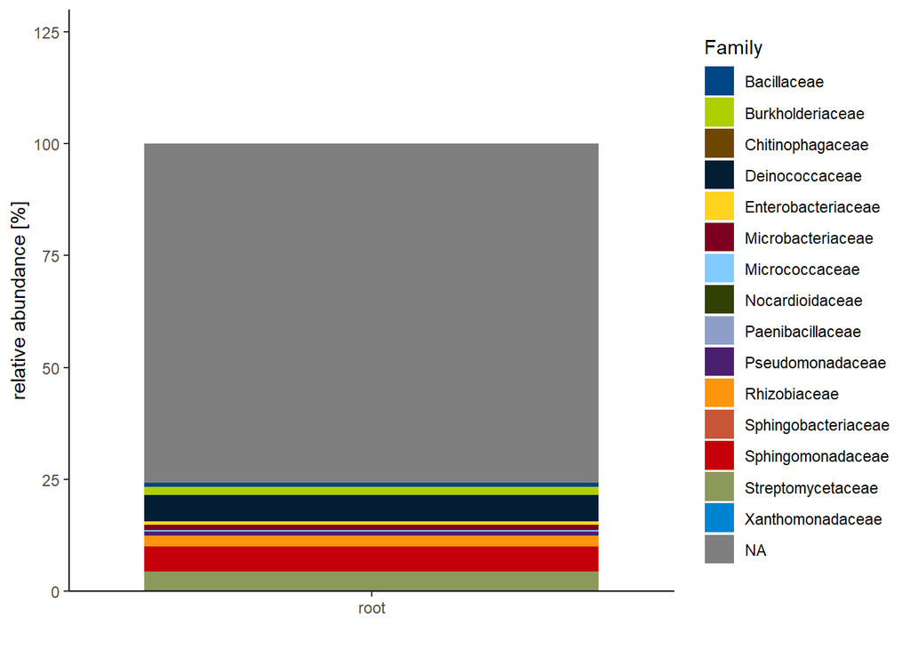

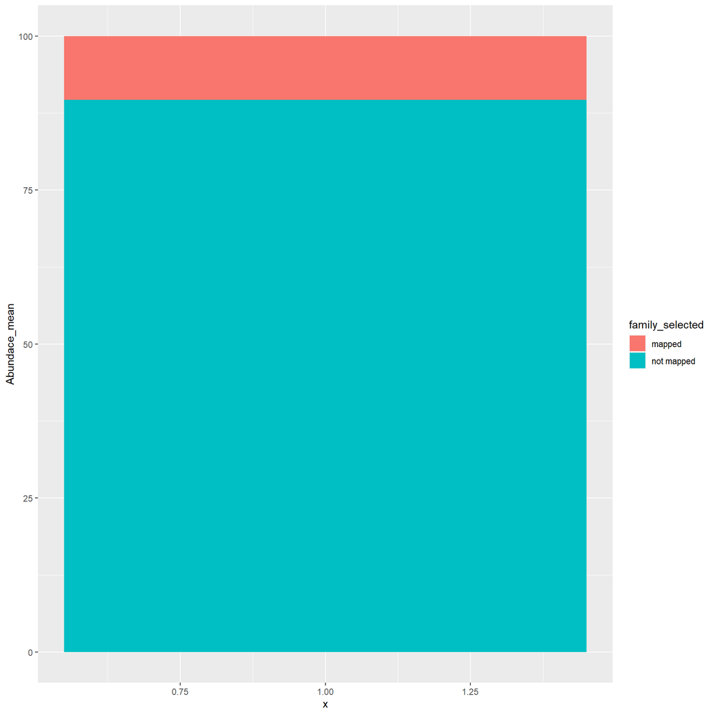

| OTU | phylum | family | genus | soil | Abundace_mean | family_selected |
| --- | --- | --- | --- | --- | --- | --- |
| ASV1 | Proteobacteria | Sphingomonadaceae | Sphingobium | BX+ | 1.9495974 | mapped |
| ASV127 | Proteobacteria | Enterobacteriaceae | NA | BX+ | 0.8513346 | mapped |
| ASV7 | Deinococcus-Thermus | Deinococcaceae | Deinococcus | BX+ | 0.7072797 | mapped |
| ASV144 | Proteobacteria | Enterobacteriaceae | Lelliottia | BX+ | 0.6897097 | mapped |
| ASV18 | Proteobacteria | Sphingomonadaceae | Sphingobium | BX+ | 0.5629931 | mapped |
| ASV32 | Proteobacteria | Sphingomonadaceae | Sphingobium | BX+ | 0.3901038 | mapped |
| ASV21 | Firmicutes | Bacillaceae | Bacillus | BX+ | 0.3383175 | mapped |
| ASV61 | Proteobacteria | Pseudomonadaceae | Pseudomonas | BX+ | 0.3073325 | mapped |
| ASV50 | Proteobacteria | Burkholderiaceae | Pseudoduganella | BX+ | 0.2806934 | mapped |
| ASV20 | Proteobacteria | Rhizobiaceae | Allorhizobium-Neorhizobium-Pararhizobium-Rhizobium | BX+ | 0.2605503 | mapped |
| ASV100 | Firmicutes | Bacillaceae | Bacillus | BX+ | 0.2403908 | mapped |
| ASV508 | Proteobacteria | Enterobacteriaceae | Enterobacter | BX+ | 0.2042336 | mapped |
| ASV85 | Firmicutes | Bacillaceae | Bacillus | BX+ | 0.1939970 | mapped |
| ASV13 | Actinobacteria | Streptomycetaceae | Streptomyces | BX+ | 0.1882433 | mapped |
| ASV79 | Proteobacteria | Burkholderiaceae | Pseudoduganella | BX+ | 0.1738853 | mapped |
| ASV653 | Proteobacteria | Enterobacteriaceae | Cedecea | BX+ | 0.1733858 | mapped |
| ASV25 | Actinobacteria | Streptomycetaceae | Streptomyces | BX+ | 0.1556582 | mapped |
| ASV582 | Proteobacteria | Enterobacteriaceae | Enterobacter | BX+ | 0.1543079 | mapped |
| ASV126 | Firmicutes | Bacillaceae | Bacillus | BX+ | 0.1527923 | mapped |
| ASV173 | Actinobacteria | Micrococcaceae | Pseudarthrobacter | BX+ | 0.1416981 | mapped |
| ASV138 | Proteobacteria | Pseudomonadaceae | Pseudomonas | BX+ | 0.1050144 | mapped |
| ASV218 | Actinobacteria | Micrococcaceae | Arthrobacter | BX+ | 0.1030960 | mapped |
| ASV99 | Firmicutes | Bacillaceae | Bacillus | BX+ | 0.0894384 | mapped |
| ASV273 | Firmicutes | Bacillaceae | Bacillus | BX+ | 0.0870767 | mapped |
| ASV129 | Actinobacteria | Microbacteriaceae | Microbacterium | BX+ | 0.0845795 | mapped |
| ASV299 | Firmicutes | Bacillaceae | Bacillus | BX+ | 0.0798123 | mapped |
| ASV251 | Proteobacteria | Burkholderiaceae | Duganella | BX+ | 0.0721486 | mapped |
| ASV1020 | Proteobacteria | Enterobacteriaceae | NA | BX+ | 0.0684721 | mapped |
| ASV199 | Firmicutes | Bacillaceae | Bacillus | BX+ | 0.0599724 | mapped |
| ASV190 | Bacteroidetes | Weeksellaceae | Chryseobacterium | BX+ | 0.0587058 | mapped |

[output cut: 215 more lines]

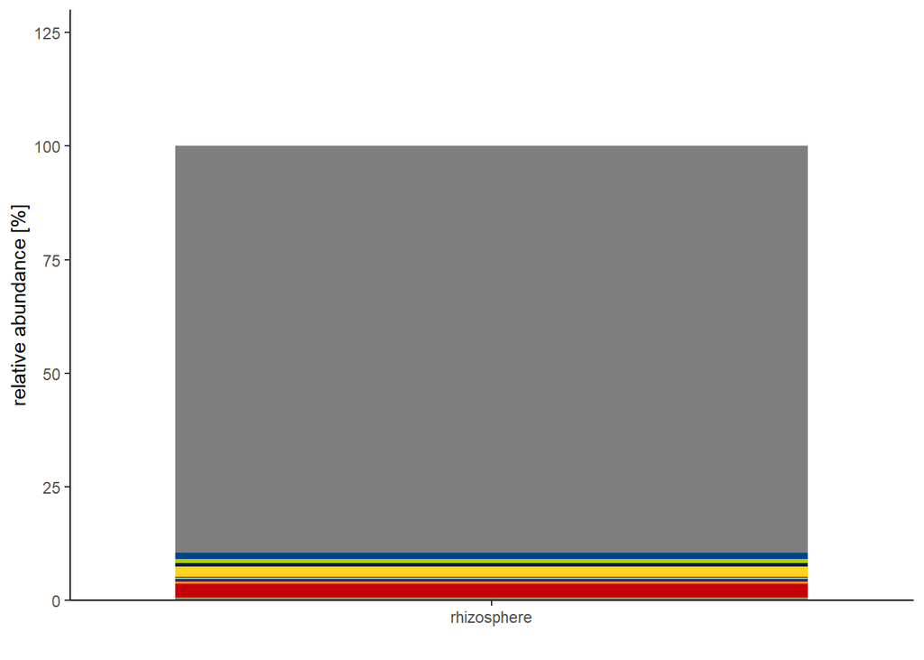